# STAT-S632

Experimental Design

# Two factors with no replication

The model is:

$$y_{ij} = \mu + \alpha_i + \beta_j + (\alpha \beta)_{ij} + \epsilon_{ij}$$

where $i = 1, ..., I$ and $j = 1, ..., J$

$\alpha$ is the effect of the first factor at level $i$ and $\beta$ is the effect of the second factor at level $j$.

R example:

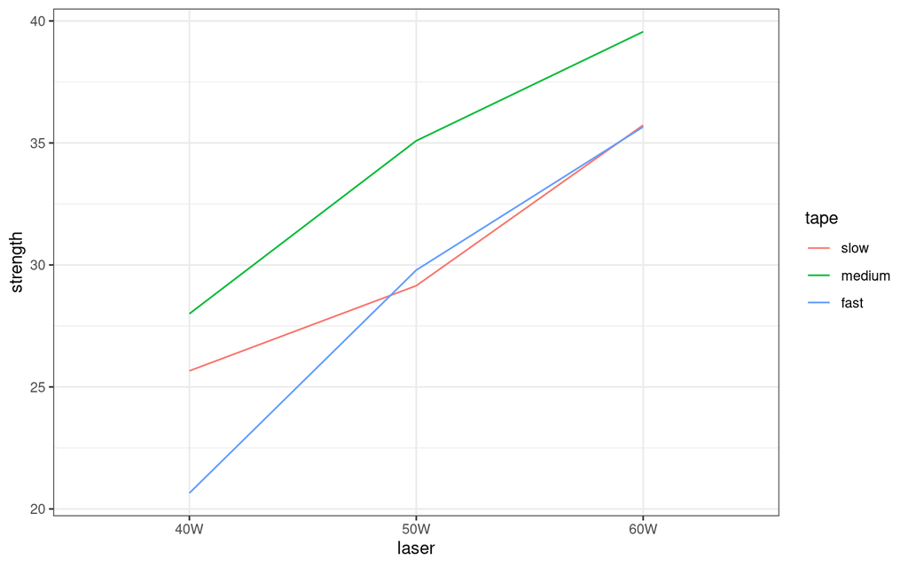

```r
# library(faraway)
library(ggplot2)
library(car)

theme_set(theme_bw())

data(composite, package = 'faraway')

ggplot(composite) +
  geom_line(aes(x = laser, y = strength, group = tape, colour = tape))
```

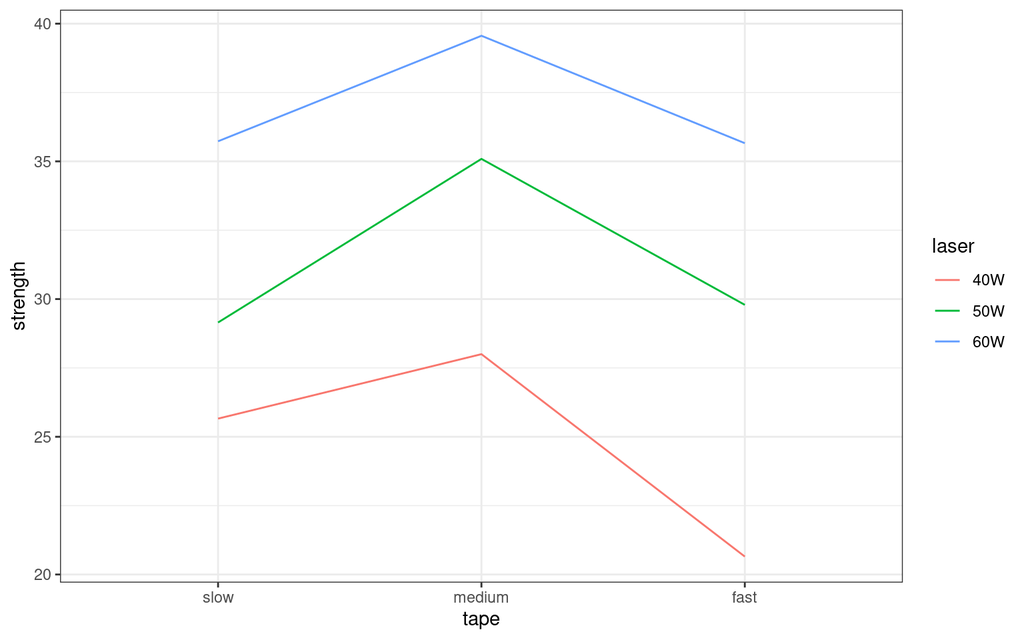

```r
ggplot(composite) +
  geom_line(aes(x = tape, y = strength, group = laser, colour = laser))
```

```r
lmod <- lm(strength ~ laser + tape + laser:tape, data = composite)
summary(lmod)
```

```
Call:
lm(formula = strength ~ laser + tape + laser:tape, data = composite)

Residuals:
ALL 9 residuals are 0: no residual degrees of freedom!

Coefficients:
                    Estimate Std. Error t value Pr(>|t|)
(Intercept)            25.66        NaN     NaN      NaN
laser50W                3.49        NaN     NaN      NaN
laser60W               10.07        NaN     NaN      NaN
tapemedium              2.34        NaN     NaN      NaN
tapefast               -5.01        NaN     NaN      NaN
laser50W:tapemedium     3.60        NaN     NaN      NaN
laser60W:tapemedium     1.49        NaN     NaN      NaN
laser50W:tapefast       5.65        NaN     NaN      NaN
laser60W:tapefast       4.94        NaN     NaN      NaN

Residual standard error: NaN on 0 degrees of freedom
Multiple R-squared:      1, Adjusted R-squared:    NaN
F-statistic:   NaN on 8 and 0 DF,  p-value: NA
```

```r
lmod <- lm(strength ~ laser + tape, data = composite)
summary(lmod)
```

```
Call:
lm(formula = strength ~ laser + tape, data = composite)

Residuals:
       1        2        3        4        5        6        7        8
 1.74222 -1.34111 -0.40111  0.04556  0.56222 -0.60778 -1.78778  0.77889
       9
 1.00889

Coefficients:
            Estimate Std. Error t value Pr(>|t|)
(Intercept)   23.918      1.208  19.803 3.84e-05 ***
laser50W       6.573      1.323   4.968 0.007661 **
laser60W      12.213      1.323   9.231 0.000765 ***
tapemedium     4.037      1.323   3.051 0.037991 *
tapefast      -1.480      1.323  -1.119 0.325944
---
Signif. codes:  0 '***' 0.001 '**' 0.01 '*' 0.05 '.' 0.1 ' ' 1

Residual standard error: 1.62 on 4 degrees of freedom
Multiple R-squared:  0.963, Adjusted R-squared:  0.9259
F-statistic:    26 on 4 and 4 DF,  p-value: 0.004013
```

## Randomized block design

Given …

- one treatment factor $\tau$ with $t$ levels
- one blocking factor $\beta$ with $r$ levels
- one observation on each treatment in each block
- limited ability to determine interactions between treatment and group (e.g., not enough observations)

The model is:

$$y_{ij} = \mu + \tau_i + \beta_j + \epsilon_{ij}$$

where $i = 1, ..., t$ and $j = 1, ..., r$

$\mu$ is the overall mean, $\tau_i$ is the treatment effect, and $\beta$ is the blocking effect

Can check for treatment effects and blocking effects (but not interactions)

Blocking effects are a feature of experimental units—cannot regain degrees of freedom if blocking is not significant

```r
data(oatvar, package = 'faraway')
summary(oatvar)
```

```
     yield       block      variety
 Min.   :220.0   I  :8   1      : 5
 1st Qu.:319.8   II :8   2      : 5
 Median :341.0   III:8   3      : 5
 Mean   :354.1   IV :8   4      : 5
 3rd Qu.:395.8   V  :8   5      : 5
 Max.   :488.0           6      : 5
                         (Other):10
```

```r
xtabs(yield ~ variety + block, oatvar)
```

```
       block
variety   I  II III  IV   V
      1 296 357 340 331 348
      2 402 390 431 340 320
      3 437 334 426 320 296
      4 303 319 310 260 242
      5 469 405 442 487 394
      6 345 342 358 300 308
      7 324 339 357 352 220
      8 488 374 401 338 320
```

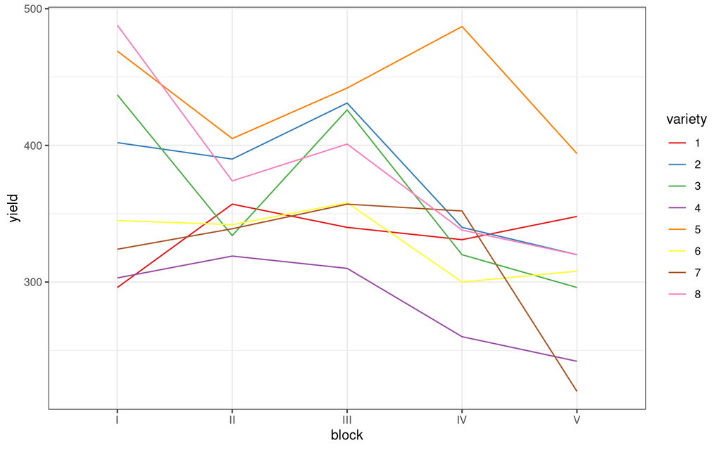

```r
ggplot(oatvar) +
  geom_line(aes(x = block, y = yield, group = variety, colour = variety)) +
  scale_colour_brewer(palette = 'Set1')
```

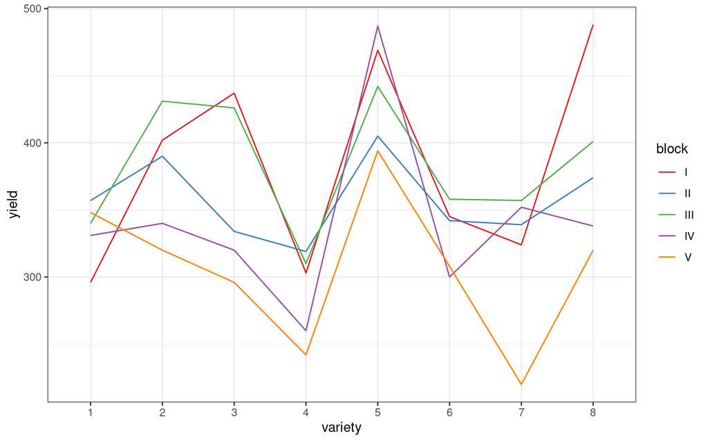

```r
ggplot(oatvar) +
  geom_line(aes(x = variety, y = yield, group = block, colour = block)) +
  scale_colour_brewer(palette = 'Set1')
```

```r
lmod <- lm(yield ~ block + variety, data = oatvar)
summary(lmod)
```

```
Call:
lm(formula = yield ~ block + variety, data = oatvar)

Residuals:
    Min      1Q  Median      3Q     Max
-67.275 -19.675  -4.637  17.725  74.925

Coefficients:
            Estimate Std. Error t value Pr(>|t|)
(Intercept)  363.275     20.027  18.139  < 2e-16 ***
blockII      -25.500     18.282  -1.395 0.174036
blockIII       0.125     18.282   0.007 0.994593
blockIV      -42.000     18.282  -2.297 0.029282 *
blockV       -77.000     18.282  -4.212 0.000238 ***
variety2      42.200     23.125   1.825 0.078707 .
variety3      28.200     23.125   1.219 0.232841
variety4     -47.600     23.125  -2.058 0.048968 *
variety5     105.000     23.125   4.541 9.73e-05 ***
variety6      -3.800     23.125  -0.164 0.870656
variety7     -16.000     23.125  -0.692 0.494701
variety8      49.800     23.125   2.154 0.040035 *
---
Signif. codes:  0 '***' 0.001 '**' 0.01 '*' 0.05 '.' 0.1 ' ' 1

Residual standard error: 36.56 on 28 degrees of freedom
Multiple R-squared:  0.7477,    Adjusted R-squared:  0.6485
F-statistic: 7.542 on 11 and 28 DF,  p-value: 7.723e-06
```

```r
anova(lmod)
```

```
Analysis of Variance Table

Response: yield
          Df Sum Sq Mean Sq F value    Pr(>F)
block      4  33396  8348.9  6.2449  0.001008 **
variety    7  77524 11074.8  8.2839 1.804e-05 ***
Residuals 28  37433  1336.9
---
Signif. codes:  0 '***' 0.001 '**' 0.01 '*' 0.05 '.' 0.1 ' ' 1
```

```r
anova(lm(yield ~ block, data = oatvar))
```

```
Analysis of Variance Table

Response: yield
          Df Sum Sq Mean Sq F value  Pr(>F)
block      4  33396  8348.9  2.5419 0.05694 .
Residuals 35 114957  3284.5
---
Signif. codes:  0 '***' 0.001 '**' 0.01 '*' 0.05 '.' 0.1 ' ' 1
```

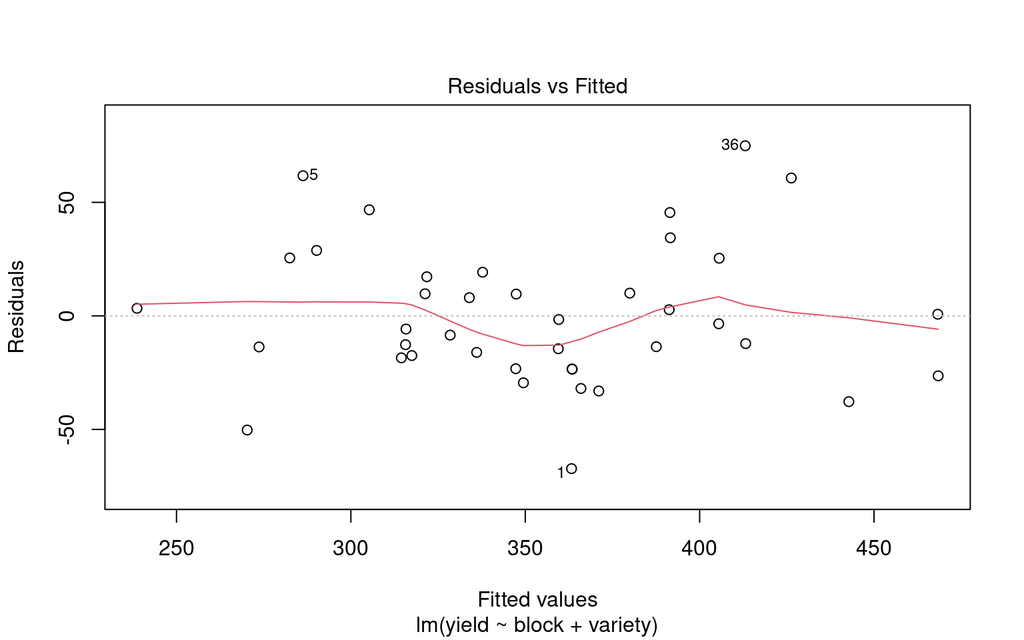

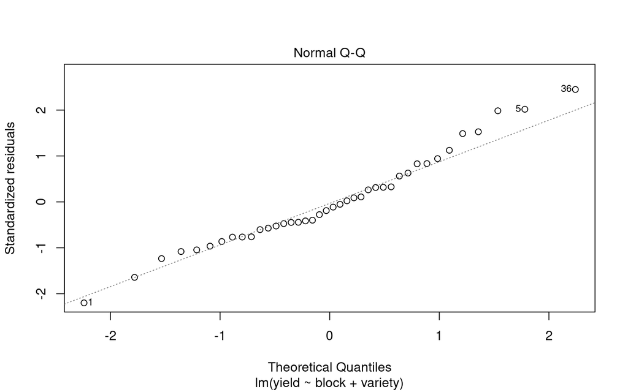

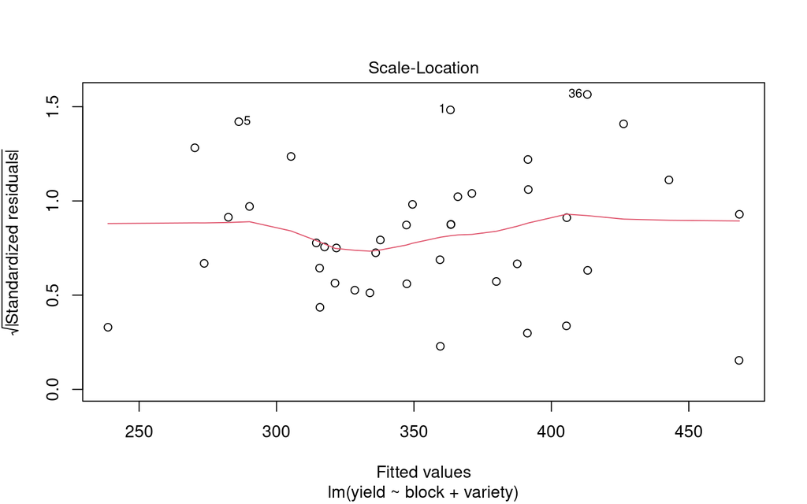

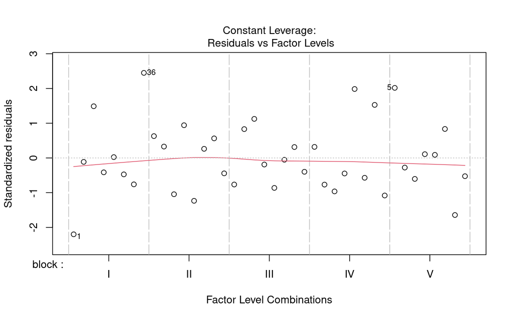

```r
plot(lmod)
```

Comparison between complete randomized design (CRD) and randomized complete block design (RCBD):

Because `block` is significant, a model with blocking would be preferred

Can also consider efficiency

$\hat{\sigma}^2_{CRD}$ vs $\hat{\sigma}^2_{CRBD}$

```r
lmcrd <- lm(yield ~ variety, data = oatvar)
anova(lmcrd, lmod)
```

```
Analysis of Variance Table

Model 1: yield ~ variety
Model 2: yield ~ block + variety
  Res.Df   RSS Df Sum of Sq      F   Pr(>F)
1     32 70829
2     28 37433  4     33396 6.2449 0.001008 **
---
Signif. codes:  0 '***' 0.001 '**' 0.01 '*' 0.05 '.' 0.1 ' ' 1
```

```r
summary(lmcrd)$sig
```

```
[1] 47.04679
```

```r
summary(lmod)$sig
```

```
[1] 36.56369
```

```r
(summary(lmcrd)$sig / summary(lmod)$sig) ** 2
```

```
[1] 1.655617
```

$\sim 66\%$ more observations are needed in CRD to get the same level of precision compared to CRBD

## Latin squares

Type of fractional factorial design for two blocking variables

Example: Compare 4 materials (which are our treatments): `A`, `B`, `C`, `D`, block 1: 4 positions `1`, `2`, `3`, `4`, block 2: 4 runs `1`, `2`, `3`, `4`, response: wear (weight of material worn)

```r
data(abrasion, package = 'faraway')
summary(abrasion)
```

```
 run   position material      wear
 1:4   1:4      A:4      Min.   :195.0
 2:4   2:4      B:4      1st Qu.:226.8
 3:4   3:4      C:4      Median :234.5
 4:4   4:4      D:4      Mean   :239.5
                         3rd Qu.:255.2
                         Max.   :274.0
```

```r
xtabs(wear ~ run + position, data = abrasion)
```

```
   position
run   1   2   3   4
  1 235 236 218 268
  2 251 241 227 229
  3 234 273 274 226
  4 195 270 230 225
```

```r
matrix(abrasion$material, 4, 4, byrow = TRUE)
```

```
     [,1] [,2] [,3] [,4]
[1,] "C"  "D"  "B"  "A"
[2,] "A"  "B"  "D"  "C"
[3,] "D"  "C"  "A"  "B"
[4,] "B"  "A"  "C"  "D"
```

Note that each treatment is assigned to each block only once

The model:

$$y_{ijk} = \mu + \tau_i + \beta_j + \gamma_k + \epsilon_{ijk}$$

$i, j, k$ all have same number of levels $1, ..., t$, but not all appear in the data

- Latin square can be more efficient than RCBD
- block sizes (levels) should be equal to treatments (levels)
- can be used to compare three treatment factors
- cannot estimate interactions

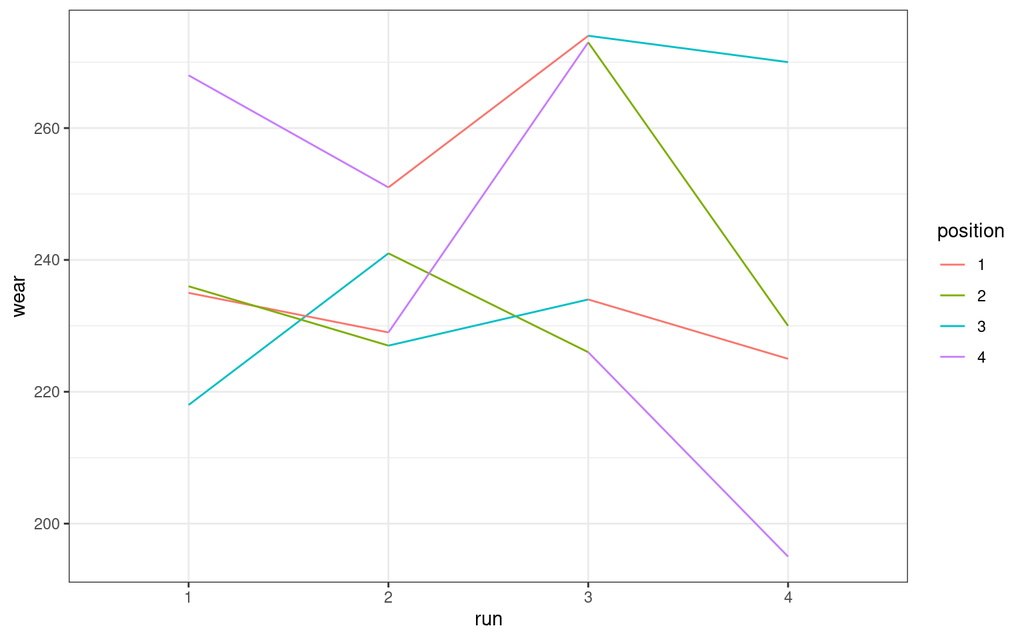

```r
ggplot(abrasion) +
  geom_line(aes(x = run, y = wear, colour = position, group = material))
```

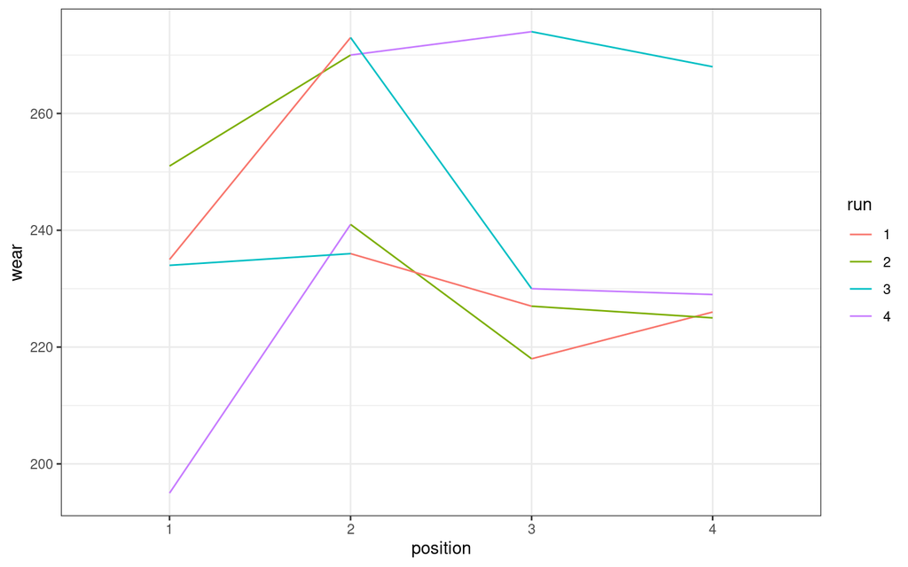

```r
ggplot(abrasion) +
  geom_line(aes(x = position, y = wear, colour = run, group = material))
```

```r
lmod <- lm(wear ~ material + run + position, data = abrasion)
summary(lmod)
```

```
Call:
lm(formula = wear ~ material + run + position, data = abrasion)

Residuals:
   Min     1Q Median     3Q    Max
-9.750 -2.250  0.250  3.688  8.000

Coefficients:
            Estimate Std. Error t value Pr(>|t|)
(Intercept)  254.750      6.187  41.174 1.37e-08 ***
materialB    -45.750      5.534  -8.267 0.000169 ***
materialC    -24.000      5.534  -4.337 0.004892 **
materialD    -35.250      5.534  -6.370 0.000703 ***
run2          -2.250      5.534  -0.407 0.698423
run3          12.500      5.534   2.259 0.064657 .
run4          -9.250      5.534  -1.671 0.145658
position2     26.250      5.534   4.743 0.003180 **
position3      8.500      5.534   1.536 0.175454
position4      8.250      5.534   1.491 0.186608
---
Signif. codes:  0 '***' 0.001 '**' 0.01 '*' 0.05 '.' 0.1 ' ' 1

Residual standard error: 7.826 on 6 degrees of freedom
Multiple R-squared:  0.9506,    Adjusted R-squared:  0.8766
F-statistic: 12.84 on 9 and 6 DF,  p-value: 0.002828
```

```r
drop1(lmod, test = 'F')
```

```
Single term deletions

Model:
wear ~ material + run + position
         Df Sum of Sq    RSS     AIC F value    Pr(>F)
<none>                 367.5  70.146
material  3    4621.5 4989.0 105.878 25.1510 0.0008498 ***
run       3     986.5 1354.0  85.012  5.3687 0.0390130 *
position  3    1468.5 1836.0  89.884  7.9918 0.0161685 *
---
Signif. codes:  0 '***' 0.001 '**' 0.01 '*' 0.05 '.' 0.1 ' ' 1
```